# Practical Machine Learning Course Project

Koji Takahashi

2018/8/11

# Prediction Assignment Writeup

## 1. Overview

The goal of this project is to predict how the six participants exercised (the “Classe” variable of the training set) using various machine learning methods. Participants were asked to perform the barbell lift correctly and incorrectly in five different ways. We predict using accelerometer data of belts, forearms, arms, dumbbells. More information is available from the website here: http://web.archive.org/web/20161224072740/http:/groupware.les.inf.puc-rio.br/har

## 2. Contents of Weight Lifting Exercises

Six young health participants were asked to perform one set of 10 repetitions of the Unilateral Dumbbell Biceps Curl in five different fashions: exactly according to the specification (Class A), throwing the elbows to the front (Class B), lifting the dumbbell only halfway (Class C), lowering the dumbbell only halfway (Class D) and throwing the hips to the front (Class E). Class A corresponds to the specified execution of the exercise, while the other 4 classes correspond to common mistakes.

## 3. Data Loading and Cleaning

### 3.1. Data Loading

The training data for this project are available here:  
https://d396qusza40orc.cloudfront.net/predmachlearn/pml-training.csv  
The test data are available here:  
https://d396qusza40orc.cloudfront.net/predmachlearn/pml-testing.csv

```r
## Download and loading
# Download and loading the dataset
trainingUrl <- "https://d396qusza40orc.cloudfront.net/predmachlearn/pml-training.csv"
quizUrl <- "https://d396qusza40orc.cloudfront.net/predmachlearn/pml-testing.csv"

trainingData <- read.csv(url(trainingUrl), na.strings = c("NA", "#DIV/0!", ""))
quizData <- read.csv(url(quizUrl), na.strings = c("NA", "#DIV/0!", ""))
```

### 3.2. Data Cleaning

We will remove the columns that are the near zero variance predictors, the columns containing NA and the first 6 columns that are not predictor.

```r
# Data Cleaning
nzv <- nearZeroVar(trainingData, saveMetrics = F)
trainingData <- trainingData[, -nzv]
trainingData <- trainingData[, colSums(is.na(trainingData)) == 0]
trainingData <- trainingData[, -(1:6)] # not predictor

quizData <- quizData[, -nzv]
quizData <- quizData[, colSums(is.na(quizData)) == 0]
quizData <- quizData[, -(1:6)] # not predictor
```

### 3.3. trainSet and testSet

We divide the trainingData into trainSet and testSet.

```r
# trainSet and testSet
inTrain <- createDataPartition(trainingData$classe, p = 0.7, list = FALSE)
trainSet <- trainingData[inTrain, ]
testSet <- trainingData[-inTrain, ]
```

## 4. Exploratory Analysis

The data set has biased data distributions like the roll_belt column. We will preprocess the data set using center, scale and BoxCox if necessary, and then we will make the model.

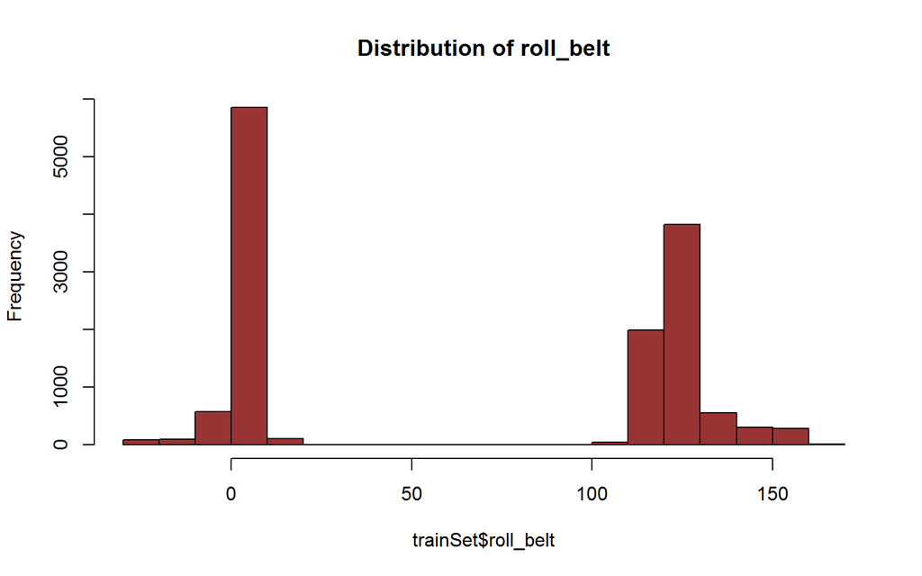

## 5. Prediction Model Building

We will create models using the following 7 methods with an accuracy of approximately 0.7 or higher:

- Random Forest (rf)
- Gradient Boosting Machine (gbm)
- eXtreme Gradient Boosting (xgbTree)
- Neural Network (nnet)
- Support Vector Machine (svmRadial)
- k Nearest Neighbor (knn)
- Linear Discriminant Analysis (lda)

We will specify trainControl as cross validation (“cv” or “repeatedcv”). Also, to save time, we will set “number = 3” (3-fold cross validation).  
Since Decision Tree (rpart) was low in accuracy, it was excluded.

```r
## Model building "rpart","rf","gbm","xgb","nnet","svmRadial","knn","lda"
# trainControl (excluding knn(repeatedcv))
cvControl = trainControl(method = "cv", number = 3, allowParallel = TRUE)
```

### 5.1. Random Forest

We will optimize mtry using the tuneRF function, and then create an rf model.  
According to plot of rfMod, the variables contributing to classification are roll_belt, pitch_forearm, yaw_belt, magnet_dumbbell_z, magnet_dumbbell_y and so on.

```r
# rf
set.seed(7)
tune_mtry <- tuneRF(trainSet[,-53], trainSet[,53],doBest=T)
```

```
## mtry = 7  OOB error = 0.76%
## Searching left ...
## mtry = 4     OOB error = 0.92%
## -0.2095238 0.05
## Searching right ...
## mtry = 14    OOB error = 0.72%
## 0.05714286 0.05
## mtry = 28    OOB error = 1.04%
## -0.4444444 0.05
```

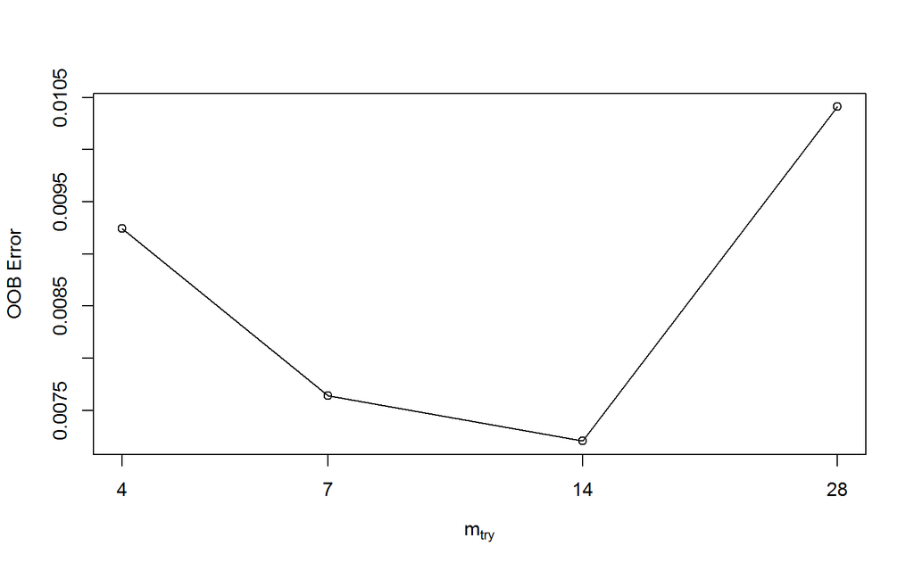

```r
rfMod <-randomForest(classe ~ ., trainSet, mtry=tune_mtry$mtry,
                     importance=T, trControl = cvControl)
rfPred <- predict(rfMod, testSet)
confusionMatrix(rfPred, testSet$classe)$overall
```

```
##       Accuracy          Kappa  AccuracyLower  AccuracyUpper   AccuracyNull
##      0.9945624      0.9931213      0.9923324      0.9962778      0.2844520
## AccuracyPValue  McnemarPValue
##      0.0000000            NaN
```

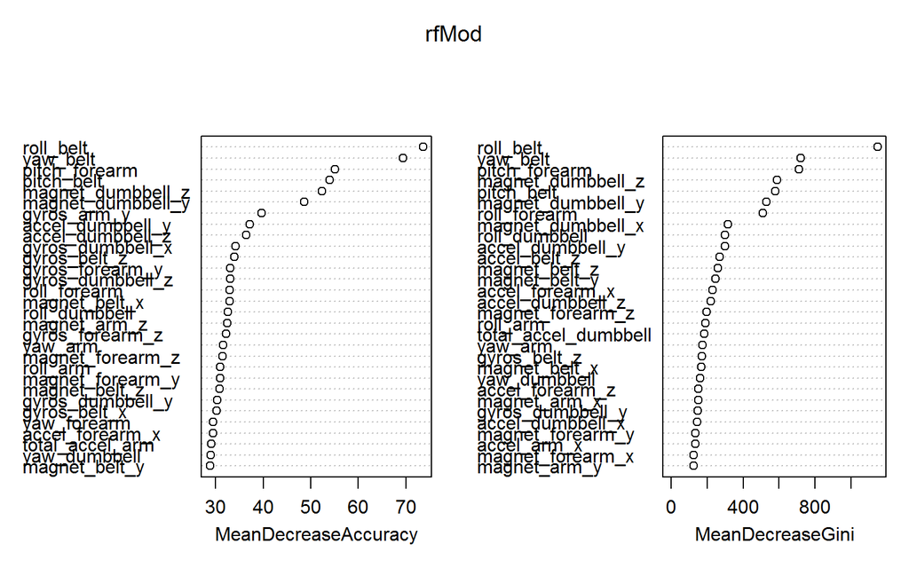

```r
varImpPlot(rfMod)
```

### 5.2. Gradient Boosting Machine

Refer to the appendix for the following analysis code.

```
##       Accuracy          Kappa  AccuracyLower  AccuracyUpper   AccuracyNull
##   9.700935e-01   9.621549e-01   9.654170e-01   9.742958e-01   2.844520e-01
## AccuracyPValue  McnemarPValue
##   0.000000e+00   3.278529e-08
```

### 5.3. eXtreme Gradient Boosting

```
##       Accuracy          Kappa  AccuracyLower  AccuracyUpper   AccuracyNull
##      0.9957519      0.9946267      0.9937353      0.9972490      0.2844520
## AccuracyPValue  McnemarPValue
##      0.0000000            NaN
```

### 5.4. Neural Network

The accuracy of the neural network has greatly improved by using “BoxCox”, “center” and “scale”.

```
##       Accuracy          Kappa  AccuracyLower  AccuracyUpper   AccuracyNull
##   7.242141e-01   6.495813e-01   7.126018e-01   7.356038e-01   2.844520e-01
## AccuracyPValue  McnemarPValue
##   0.000000e+00   8.226197e-44
```

### 5.5. Support Vector Machine

```
##       Accuracy          Kappa  AccuracyLower  AccuracyUpper   AccuracyNull
##      0.9937128      0.9920471      0.9913443      0.9955695      0.2844520
## AccuracyPValue  McnemarPValue
##      0.0000000            NaN
```

### 5.6. k Nearest Neighbor

```
##       Accuracy          Kappa  AccuracyLower  AccuracyUpper   AccuracyNull
##   9.672048e-01   9.585082e-01   9.623317e-01   9.716071e-01   2.844520e-01
## AccuracyPValue  McnemarPValue
##   0.000000e+00   5.392638e-10
```

### 5.7. Linear Discriminant Analysis

```
##       Accuracy          Kappa  AccuracyLower  AccuracyUpper   AccuracyNull
##   7.056924e-01   6.275706e-01   6.938640e-01   7.173166e-01   2.844520e-01
## AccuracyPValue  McnemarPValue
##   0.000000e+00   9.027509e-66
```

## 6. Expected out of sample error

The top three models (rf, xgbTree, svmRadial) exceed accuracy 0.99. It is surprisingly high accuracy. It is the result predicted with testSet using the model made with trainSet, so there is no overfitting.  
I calculated the average of confusionMatrix of these 3 models. The distribution of error data is not uniform, and the number of errors in the following example is relatively large.

- Between Class A (the Unilateral Dumbbell Biceps Curl) and Class B (throwing the elbows to the front).
- Between Class B (throwing the elbows to the front) and Class C (lifting the dumbbell only halfway)
- Between Class C (lifting the dumbbell only halfway) and Class D (lowering the dumbbell only halfway).

```
##           Reference
## Prediction      A      B      C      D      E
##          A 1672.0    4.3    0.0    0.0    0.0
##          B    1.3 1132.7    5.0    0.0    0.0
##          C    0.7    1.7 1019.3   10.3    1.7
##          D    0.0    0.0    1.7  952.3    3.0
##          E    0.0    0.3    0.0    1.3 1077.3
```

## 7. Applying the prediction Models to the Test Cases

The prediction of 20 test cases is decided by the majority vote of prediction of the 7 models. The matchRate column is the match rate of the majority vote result and prediction of each model. The matchRate and the accuracy are roughly in agreement.

```
##          1 2 3 4 5 6 7 8 9 10 11 12 13 14 15 16 17 18 19 20 matchRate
## RF       B A B A A E D B A  A  B  C  B  A  E  E  A  B  B  B      1.00
## GBM      B A B A A E D B A  A  B  C  B  A  E  E  A  B  B  B      1.00
## XGB      B A B A A E D B A  A  B  C  B  A  E  E  A  B  B  B      1.00
## NNET     B A A A A E D B A  A  A  C  C  A  E  E  A  C  B  B      0.80
## SVM      B A B A A E D B A  A  B  C  B  A  E  E  A  B  B  B      1.00
## KNN      B A A A A E D B A  A  B  C  B  A  E  E  A  B  B  B      0.95
## LDA      B A B C C C D D A  A  D  A  B  A  E  A  A  B  B  B      0.65
## majority B A B A A E D B A  A  B  C  B  A  E  E  A  B  B  B      1.00
##          accuracy
## RF          0.995
## GBM          0.97
## XGB         0.996
## NNET        0.724
## SVM         0.994
## KNN         0.967
## LDA         0.706
## majority        -
```

# Appendix

The whole code is shown below.

```r
## Load library
library(caret)
library(randomForest)
library(e1071)
library(gbm)
library(xgboost)
library(Matrix)
library(dplyr)
library(rattle)
library(ParallelForest)
library(nnet)
library(klaR)
library(doParallel)
library(tidyverse)

cl <- makeCluster(2)
registerDoParallel(cl)

## 3. Download and loading
# 3.1. Data Loading
trainingUrl <- "https://d396qusza40orc.cloudfront.net/predmachlearn/pml-training.csv"
quizUrl <- "https://d396qusza40orc.cloudfront.net/predmachlearn/pml-testing.csv"

trainingData <- read.csv(url(trainingUrl), na.strings = c("NA", "#DIV/0!", ""))
quizData <- read.csv(url(quizUrl), na.strings = c("NA", "#DIV/0!", ""))

# 3.2. Data Cleaning
nzv <- nearZeroVar(trainingData, saveMetrics = F)
trainingData <- trainingData[, -nzv]
trainingData <- trainingData[, colSums(is.na(trainingData)) == 0]
trainingData <- trainingData[, -(1:6)] # not predictor

quizData <- quizData[, -nzv]
quizData <- quizData[, colSums(is.na(quizData)) == 0]
quizData <- quizData[, -(1:6)] # not predictor

# 3.3. trainSet and testSet
inTrain <- createDataPartition(trainingData$classe, p = 0.7, list = FALSE)
trainSet <- trainingData[inTrain, ]
testSet <- trainingData[-inTrain, ]

## 4. Exploratory Analysis
hist(trainSet$roll_belt, main="Distribution of roll_belt",
     col="#993435")

## 5. Prediction Model Building "rf","gbm","xgb","nnet","svmRadial","knn","lda"
# trainControl (excluding knn(repeatedcv))
cvControl = trainControl(method = "cv", number = 3, allowParallel = TRUE)

# 5.1. rf
set.seed(7)
tune_mtry <- tuneRF(trainSet[,-53], trainSet[,53],doBest=T)
rfMod <-randomForest(classe ~ ., trainSet, mtry=tune_mtry$mtry,
                     importance=T, trControl = cvControl)
rfPred <- predict(rfMod, testSet)
confusionMatrix(rfPred, testSet$classe)$overall
varImpPlot(rfMod)

# 5.2. gbm
set.seed(7)
gbmMod <- train(classe ~ ., method = "gbm", data = trainSet,
                trControl = cvControl)
gbmPred <- predict(gbmMod, testSet)
confusionMatrix(gbmPred, testSet$classe)$overall

# 5.3. xgb
set.seed(7)
xgbMod <- train(classe ~ ., method = "xgbTree", data = trainSet,
                metric = "Accuracy", trControl = cvControl)
xgbPred <- predict(xgbMod, testSet)
confusionMatrix(data = xgbPred, reference = testSet$classe,
                dnn = c("Prediction", "Actual"),
                mode = "prec_recall")$overall

# 5.4. nnet
set.seed(7)
nnetMod <- train(classe ~ ., method = "nnet", data = trainSet, trace=F,
                 trControl = cvControl,
                 preProcess = c("BoxCox","center","scale"))
nnetPred <- predict(nnetMod, testSet)
confusionMatrix(nnetPred, testSet$classe)$overall

# 5.5. svm
set.seed(7)
svmMod <- train(classe ~ ., method = "svmRadial", data = trainSet,
                trControl = cvControl, trace=T, tuneLength=10)
svmPred <- predict(svmMod, testSet)
confusionMatrix(svmPred, testSet$classe)$overall

# 5.6. knn
set.seed(7)
knnctrl <- trainControl(method="repeatedcv", number = 3, repeats = 5)
knnMod <- train(classe ~ ., method = "knn", data = trainSet,
                trControl = knnctrl,
                preProcess = c("center","scale"))
knnPred <- predict(knnMod, newdata = testSet)
confusionMatrix(knnPred, testSet$classe)$overall

# 5.7. lda
set.seed(7)
ldaMod <- train(classe ~ ., method = "lda", data = trainSet,
                trControl = cvControl,
                preProcess = c("BoxCox","center","scale"))
ldaPred <- predict(ldaMod, testSet)
confusionMatrix(ldaPred, testSet$classe)$overall

## 6. Expected out of sample error
meanTable <- (confusionMatrix(rfPred, testSet$classe)$table +
                      confusionMatrix(xgbPred, testSet$classe)$table +
                      confusionMatrix(svmPred, testSet$classe)$table) / 3
meanTable <- round(meanTable, digits = 1); meanTable

## 7. Applying the prediction Models to the Test Cases
RF <- predict(rfMod, quizData)
GBM <- predict(gbmMod, quizData)
XGB <- predict(xgbMod, quizData)
NNET <- predict(nnetMod, quizData)
SVM <- predict(svmMod, quizData)
KNN <- predict(knnMod, quizData)
LDA <- predict(ldaMod, quizData)

df <- data.frame(RF, GBM, XGB, NNET, SVM, KNN, LDA)
df <- as.data.frame(t(df))

majority <- c()
for (i in 1:20) {
        majority <- c(majority, names(which.max(table(df[, i]))))
}
majority <- as.data.frame(t(data.frame(majority)))
colnames(majority) <- names(df)
df <- rbind(df, majority)
nmajority <- c(2,1,2,1,1,5,4,2,1,1,2,3,2,1,5,5,1,2,2,2)
ML <- list(RF,GBM,XGB,NNET,SVM,KNN,LDA)
matchRate <- c()
for (i in ML) {
        match_i <- sum(as.numeric(i) == nmajority)
        matchRate <- c(matchRate, match_i)
}
matchRate <- c(matchRate, 20)
matchRate <- matchRate / 20

accuracy <- c()
MLpred <- list(rfPred, gbmPred, xgbPred, nnetPred, svmPred,
               knnPred, ldaPred)
for (i in MLpred) {
        conf_i <- confusionMatrix(i, testSet$classe)$overall[1]
        accuracy <- c(accuracy, conf_i)
}
accuracy <- round(accuracy, digits = 3)
accuracy <- c(accuracy, "-")
df <- cbind(df, matchRate, accuracy)
print(df)

stopCluster(cl)
registerDoSEQ()
```